# 1-2) 데이터 준비

## Mnist 숫자 손글씨 dataset 불러오기

< MNIST >

- 28*28 사이즈 손글씨 데이터 셋
- 0-9까지 10개의 클래스를 가지고 있음
- 색상 채널이 없는 흑백 이미지

```python
import tensorflow as tf
from tensorflow import keras
```

```python
import numpy as np
import matplotlib.pyplot as plt
```

```python
print(tf.__version__)
```

```
2.0.0
```

```python
mnist = keras.datasets.mnist
```

```python
(x_train, y_train), (x_test, y_test) = mnist.load_data()
# mnist 데이터 로드
# x_train은 train의 영상 데이터를 의미
# y_train은 해당 영상 데이터의 label을 의미함
# x_train에는 예를 들어 0이란 이미지가 있고, y_train은 해당 이미지가 무엇인지 나타나있음
```

```python
print(len(x_train)) # x_train 배열의 크기 출력 : 학습이미지가 60,000장
```

```
60000
```

```python
print(len(x_test)) # 테스트 이미지가 10,000장
```

```
10000
```

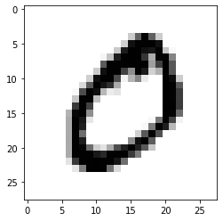

```python
plt.imshow(x_train[1], cmap=plt.cm.binary)
# x_train[1] : x_train 행렬의 2번째 이미지를 의미
# camp를 binary 타입으로 지정 -> minst는 흑백영상이기 떄문
plt.show()
```

```python
print(y_train[1])  # y항목에는 x항목에 들어잇는 이미지에 대응하는 실제 숫자가 담겨있음
```

```
0
```

```python
print(y_train[15])
```

```
7
```

```python
print(x_train[1])
```

```
[[  0   0   0   0   0   0   0   0   0   0   0   0   0   0   0   0   0   0
    0   0   0   0   0   0   0   0   0   0]
 [  0   0   0   0   0   0   0   0   0   0   0   0   0   0   0   0   0   0
    0   0   0   0   0   0   0   0   0   0]
 [  0   0   0   0   0   0   0   0   0   0   0   0   0   0   0   0   0   0
    0   0   0   0   0   0   0   0   0   0]
 [  0   0   0   0   0   0   0   0   0   0   0   0   0   0   0   0   0   0
    0   0   0   0   0   0   0   0   0   0]
 [  0   0   0   0   0   0   0   0   0   0   0   0   0   0   0  51 159 253
  159  50   0   0   0   0   0   0   0   0]
 [  0   0   0   0   0   0   0   0   0   0   0   0   0   0  48 238 252 252
  252 237   0   0   0   0   0   0   0   0]
 [  0   0   0   0   0   0   0   0   0   0   0   0   0  54 227 253 252 239
  233 252  57   6   0   0   0   0   0   0]
 [  0   0   0   0   0   0   0   0   0   0   0  10  60 224 252 253 252 202
   84 252 253 122   0   0   0   0   0   0]
 [  0   0   0   0   0   0   0   0   0   0   0 163 252 252 252 253 252 252
   96 189 253 167   0   0   0   0   0   0]
 [  0   0   0   0   0   0   0   0   0   0  51 238 253 253 190 114 253 228
   47  79 255 168   0   0   0   0   0   0]
 [  0   0   0   0   0   0   0   0   0  48 238 252 252 179  12  75 121  21
    0   0 253 243  50   0   0   0   0   0]
 [  0   0   0   0   0   0   0   0  38 165 253 233 208  84   0   0   0   0
    0   0 253 252 165   0   0   0   0   0]
 [  0   0   0   0   0   0   0   7 178 252 240  71  19  28   0   0   0   0
    0   0 253 252 195   0   0   0   0   0]
 [  0   0   0   0   0   0   0  57 252 252  63   0   0   0   0   0   0   0
    0   0 253 252 195   0   0   0   0   0]
 [  0   0   0   0   0   0   0 198 253 190   0   0   0   0   0   0   0   0
    0   0 255 253 196   0   0   0   0   0]
 [  0   0   0   0   0   0  76 246 252 112   0   0   0   0   0   0   0   0
    0   0 253 252 148   0   0   0   0   0]
 [  0   0   0   0   0   0  85 252 230  25   0   0   0   0   0   0   0   0
    7 135 253 186  12   0   0   0   0   0]
 [  0   0   0   0   0   0  85 252 223   0   0   0   0   0   0   0   0   7
  131 252 225  71   0   0   0   0   0   0]
 [  0   0   0   0   0   0  85 252 145   0   0   0   0   0   0   0  48 165
  252 173   0   0   0   0   0   0   0   0]
 [  0   0   0   0   0   0  86 253 225   0   0   0   0   0   0 114 238 253
  162   0   0   0   0   0   0   0   0   0]
 [  0   0   0   0   0   0  85 252 249 146  48  29  85 178 225 253 223 167
   56   0   0   0   0   0   0   0   0   0]
 [  0   0   0   0   0   0  85 252 252 252 229 215 252 252 252 196 130   0
    0   0   0   0   0   0   0   0   0   0]
 [  0   0   0   0   0   0  28 199 252 252 253 252 252 233 145   0   0   0
    0   0   0   0   0   0   0   0   0   0]
 [  0   0   0   0   0   0   0  25 128 252 253 252 141  37   0   0   0   0
    0   0   0   0   0   0   0   0   0   0]
 [  0   0   0   0   0   0   0   0   0   0   0   0   0   0   0   0   0   0
    0   0   0   0   0   0   0   0   0   0]
 [  0   0   0   0   0   0   0   0   0   0   0   0   0   0   0   0   0   0
    0   0   0   0   0   0   0   0   0   0]
 [  0   0   0   0   0   0   0   0   0   0   0   0   0   0   0   0   0   0
    0   0   0   0   0   0   0   0   0   0]
 [  0   0   0   0   0   0   0   0   0   0   0   0   0   0   0   0   0   0
    0   0   0   0   0   0   0   0   0   0]]
```

```
10001 번째 이미지의 숫자는 바로 3 입니다.
```

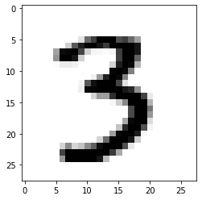

```python
# index에서 0~59999 사이 숫자를 지정하세요
index=10000
plt.imshow(x_train[index],cmap=plt.cm.binary)
plt.show
print((index+1), '번째 이미지의 숫자는 바로', y_train[index], '입니다.')
```

## 학습용 데이터와 시험용 데이터

```python
(x_train, y_train), (x_test, y_test) = mnist.load_data()
# minst.load_data() 함수를 통해 학습용 데이터 (x_train, y_train)와 시험용 데이터 (x_test, y_test) 받아드림
```

```python
# 학습용 데이터는 몇 장인지
print(x_train.shape) #28*28 크기의 숫자가 60,000개 있음
```

```
(60000, 28, 28)
```

```python
# 시험용 데이터 개수 확인하고 싶을 경우
print(x_test.shape)
```

```
(10000, 28, 28)
```

## 데이터 전처리

```python
# 손글씨 이미지의 픽셀값 확인
# 픽셀 값은 0~255 사이의 값을 가짐
print('최솟값:', np.min(x_train), '최대값:', np.max(x_train))
```

```
최솟값: 0 최대값: 255
```

```python
# 정규화 시키기
# mnist 데이터는 0~255 범위에 있으므로 데이터를 255.0으로 나눠서 정규화시키면 됨
#x_train_norm, x_test_norm = x_train/255.0 # 255로 x_train과 x_test를 한번에 나누겠다.
# x_test/255.0 으로 나눔
```

```python
x_train_1, x_test_1 = x_train/255.0, x_test/255.0
```

```python
print('최소값:',np.min(x_train_1), ' 최대값:',np.max(x_train_1))
```

```
최소값: 0.0  최대값: 1.0
```

# 1-3) 딥러닝 네트워크 설계

```python
model=keras.models.Sequential()
```

```python
model=keras.models.Sequential()
model.add(keras.layers.Conv2D(16, (3,3), activation='relu', input_shape=(28,28,1)))
#16개의 이미지 특징 # 활성함수(activation)은 relu = rectified linear unit 선형 유닛
model.add(keras.layers.MaxPool2D(2,2))
#MaxPooling : 해당 영역에서 최댓값을 찾는 방법
model.add(keras.layers.Conv2D(32, (3,3), activation='relu')) #32개의 이미지 특징
model.add(keras.layers.MaxPooling2D((2,2)))
model.add(keras.layers.Flatten()) #flatten() : 다차원을 1차원으로 품
model.add(keras.layers.Dense(32, activation='relu')) #dense 레이어가 클수록 복잡한 분류기를 만들 수 있음
model.add(keras.layers.Dense(10, activation='softmax'))
print('Model에 추가된 Layer 개수: ', len(model.layers))
model.summary()
```

```
Model에 추가된 Layer 개수:  7
Model: "sequential_1"
_________________________________________________________________
Layer (type)                 Output Shape              Param #
=================================================================
conv2d (Conv2D)              (None, 26, 26, 16)        160
_________________________________________________________________
max_pooling2d (MaxPooling2D) (None, 13, 13, 16)        0
_________________________________________________________________
conv2d_1 (Conv2D)            (None, 11, 11, 32)        4640
_________________________________________________________________
max_pooling2d_1 (MaxPooling2 (None, 5, 5, 32)          0
_________________________________________________________________
flatten (Flatten)            (None, 800)               0
_________________________________________________________________
dense (Dense)                (None, 32)                25632
_________________________________________________________________
dense_1 (Dense)              (None, 10)                330
=================================================================
Total params: 30,762
Trainable params: 30,762
Non-trainable params: 0
_________________________________________________________________
```

# 1-4) 딥러닝 학습

```python
print("Before Reshape - x_train_1 shape : {}".format(x_train_1.shape))
```

```
Before Reshape - x_train_1 shape : (60000, 28, 28)
```

```python
print("Before Reshape = x_test_1 shape : {}".format(x_test_1.shape))
```

```
Before Reshape = x_test_1 shape : (10000, 28, 28)
```

```python
# 채널에 대한 정보 입력해주기 (채널 수 1 : 흑백이미지를 뜻함)
x_train_reshaped=x_train_1.reshape(-1, 28, 28, 1)
# reshape(-1) : 자동 재배열 해줌
x_test_reshaped = x_test_1.reshape(-1, 28, 28, 1)
print("After Reshape - x_train_reshaped.shape : {}".format(x_train_reshaped.shape))
print("After Reshape - x_test_reshaped.shape : {}".format(x_test_reshaped.shape))
```

```
After Reshape - x_train_reshaped.shape : (60000, 28, 28, 1)
After Reshape - x_test_reshaped.shape : (10000, 28, 28, 1)
```

<본격 학습시키기>

1) 학습 방식에 대한 환경설정 -> compile

- model함수 : 10개의 숫자 중 어느 것일지에 대한 확률값을 출력하는 함수
- optimizer (정규화)
- loss function(손실함수) : 모델 최적화에 사용되는 목적 함수로, categorical_crossentropy or mse와 같은 기존 손실 함수의 문자열을 사용할 수 있음
- metric(기준) 리스트 : 분류를 하고자 할 때 metrics=['accuracy']로 설정하면 됨
- fit : 모델을 학습시키기 위해 사용되는 함수
- fit함수 형식(data, labels, epochs, batch_size,..)

https://keras.io/ko/getting-started/sequential-model-guide/

```python
model.compile(optimizer='adam', #Optimizer는 Adam을 많이 사용함
             loss='sparse_categorical_crossentropy',
             metrics=['accuracy'])
model.fit(x_train_reshaped, y_train, epochs=10) #epochs = 10 : 60,000개의 데이터를 10번 반복하여 학습시키라는 의미
```

```
Train on 60000 samples
```

```
<tensorflow.python.keras.callbacks.History at 0x2b863ef8cc8>
```

# 1-5) 성능 확인

- 시험용 데이터 (x_test) 사용

<verbose : 얼마나 자세하게 정보를 표시할 것인가. >

- 0 = silent,
- 1 = progress bar,
- 2 = one line per epoch.

```python
test_loss, test_accuracy = model.evaluate(x_test_reshaped, y_test, verbose =2)
print("test_loss : {}".format(test_loss))
print("test_accuarcy : {}".format(test_accuracy))
```

```
10000/1 - 2s - loss: 0.0203 - accuracy: 0.9879
test_loss : 0.04057214564063143
test_accuarcy : 0.9879000186920166
```

- moder.evaluate() -> moedl.predict() : 실제로 추론한 확률분포를 출력할 수 있음
- np.argmax(a,aixs=) : 다차원 배열의 경우 차원에 따라 가장 큰 값의 인덱스들을 반환해줌

```python
predicted_result = model.predict(x_test_reshaped) # model이 추론한 확률값
predicted_labels = np.argmax(predicted_result, axis=1)
idx=0 #1번째 x_test
print('model.predict 결과 : ', predicted_result[idx])
print('실제 데이터 라벨 : ', y_test[idx])
```

```
model.predict 결과 :  [1.2784440e-10 1.5149479e-09 7.2556730e-07 1.5206418e-06 1.5870979e-09
 4.5831158e-10 1.6702960e-17 9.9999762e-01 4.2558654e-09 1.1230161e-07]
실제 데이터 라벨 :  7
```

확률값이 가장 높은 숫자가 model이 추론한 숫자가 됨

model은 입력한 이미지가 숫자 7임을 확신하고 있음

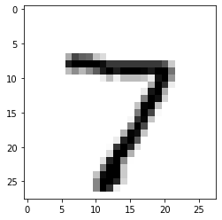

```python
# 정말 7인지 확인하기
plt.imshow(x_test[idx], cmap=plt.cm.binary)
plt.show()
```

```python
# 숫자와 실제 라벨값이 다를 경우
import random
wrong_predict_list=[]
```

```
예측확률분포 : [6.2630504e-01 5.2705190e-08 1.2488747e-06 2.8364791e-02 3.3647627e-06
 3.4514698e-01 3.2493295e-05 1.4207208e-04 4.1965077e-07 3.5394887e-06]
라벨: 5, 예측결과: 0
```

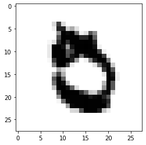

```
예측확률분포 : [1.4006340e-06 4.0560838e-07 7.7810398e-07 3.7827611e-08 4.5798188e-01
 4.3832807e-07 5.8731207e-08 9.4739647e-05 7.9297871e-07 5.4191947e-01]
라벨: 4, 예측결과: 9
```

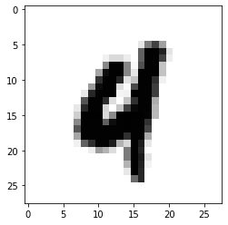

```
예측확률분포 : [7.8807712e-01 2.2815225e-10 2.3193738e-07 2.4158778e-02 4.0023526e-08
 5.3494621e-02 1.4136418e-03 6.0272157e-08 1.3285555e-01 9.5355079e-10]
라벨: 8, 예측결과: 0
```

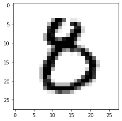

```
예측확률분포 : [5.4789782e-01 8.3277014e-12 1.7546234e-05 2.1370361e-02 3.3185384e-12
 2.9197019e-03 1.2470582e-05 2.1098292e-09 4.2655963e-01 1.2224057e-03]
라벨: 8, 예측결과: 0
```

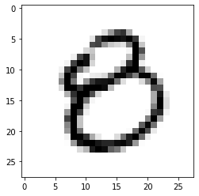

```
예측확률분포 : [6.9976007e-03 9.8878401e-04 3.1444851e-02 3.4987448e-08 5.0194814e-07
 1.4804682e-07 9.1868051e-09 9.6053141e-01 4.1949597e-06 3.2380562e-05]
라벨: 2, 예측결과: 7
```

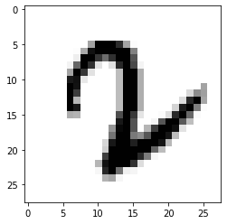

```python
for i, _ in enumerate(predicted_labels) : #i번째 test_labels과 y_test가 다른 경우만 모아라
    if predicted_labels[i] != y_test[i] :
        wrong_predict_list.append(i)

# 랜덤하게 5개 뽑기
samples = random.choices(population=wrong_predict_list, k=5)

for n in samples :
    print("예측확률분포 : " +str(predicted_result[n]))
    print("라벨: " + str(y_test[n]) + ", 예측결과: " + str(predicted_labels[n]))
    plt.imshow(x_test[n], cmap=plt.cm.binary)
    plt.show()
```

틀린 경우 model이 혼란스러워함

# 1-6) 인식률 높이기

```python
n_c_1 = 16
n_c_2 = 32
n_dense = 32
n_train_epoch = 10
```

```python
model = keras.models.Sequential()
```

```python
model.add(keras.layers.Conv2D(n_c_1, (3,3), activation='relu', input_shape=(28,28,1)))
model.add(keras.layers.Conv2D(n_c_2, (3,3), activation='relu'))
model.add(keras.layers.MaxPooling2D((2,2)))
model.add(keras.layers.Flatten())
model.add(keras.layers.Dense(n_dense, activation='relu'))
model.add(keras.layers.Dense(10, activation='softmax'))
model.summary()
```

[output not shown]

```python
n_channel_1=16
n_channel_2=32
n_dense=32
n_train_epoch=10
```

```python
model=keras.models.Sequential()
```

```python
model.add(keras.layers.Conv2D(n_channel_1, (3,3), activation='relu', input_shape=
(28,28,1)))
model.add(keras.layers.MaxPool2D(2,2))
model.add(keras.layers.Conv2D(n_channel_2, (3,3), activation='relu'))
model.add(keras.layers.MaxPooling2D((2,2)))
model.add(keras.layers.Flatten())
model.add(keras.layers.Dense(n_dense, activation='relu'))
model.add(keras.layers.Dense(10, activation='softmax'))
model.summary()
```

```
Model: "sequential_4"
_________________________________________________________________
Layer (type)                 Output Shape              Param #
=================================================================
conv2d_15 (Conv2D)           (None, 26, 26, 16)        160
_________________________________________________________________
max_pooling2d_6 (MaxPooling2 (None, 13, 13, 16)        0
_________________________________________________________________
conv2d_16 (Conv2D)           (None, 11, 11, 32)        4640
_________________________________________________________________
max_pooling2d_7 (MaxPooling2 (None, 5, 5, 32)          0
_________________________________________________________________
flatten_4 (Flatten)          (None, 800)               0
_________________________________________________________________
dense_5 (Dense)              (None, 32)                25632
_________________________________________________________________
dense_6 (Dense)              (None, 10)                330
=================================================================
Total params: 30,762
Trainable params: 30,762
Non-trainable params: 0
_________________________________________________________________
```

```python
model.compile(optimizer = 'adam',
             loss  = 'sparse_categorical_crossentropy',
             metrics=['accuracy'])
model.fit(x_train_reshaped, y_train, epochs=n_train_epoch)
```

```
Train on 60000 samples
```

```
<tensorflow.python.keras.callbacks.History at 0x2b86561ccc8>
```

```python
test_loss, test_accuracy = model.evaluate(x_test_reshaped, y_test, verbose=2)
print("test_loss: {}".format(test_loss))
print("test_accuracy:{}".format(test_accuracy))
```

```
10000/1 - 1s - loss: 0.0187 - accuracy: 0.9895
test_loss: 0.03691807326511771
test_accuracy:0.9894999861717224
```

# 1-7) 가위바위보

mkdir : make directory

```python
import os
```

```python
# PIL 라이브러리가 설치되어 있지 않다면 설치
!pip install pillow
from PIL import Image
```

```python
import os, glob
print("PIL 라이브러리 import 완료")
```

```
PIL 라이브러리 import 완료
```

```python
# 가위 이미지 28*28 사이즈 변경
import os
# 가위 이미지가 저장된 디렉토리 아래의 jpg읽기
images = glob.glob('C:/Users/User/Desktop/rock_scissor_paper/scissor/*.jpg')
```

```python
images = glob.glob('C:/Users/User/Desktop/rock_scissor_paper/scissor/*.jpg')
target_size = (28,28)
for img in images :
    old_img=Image.open(img)
    new_img=old_img.resize(target_size, Image.ANTIALIAS)
    new_img.save(img, "JPEG")
print("가위 이미지 resize 완료")
```

```
가위 이미지 resize 완료
```

-> PermissionError 났을 경우 : scissor 파일이 아닌 폴더를 불러올 경우 에러남 따라서 경로를 폴더 안에 있는 파일들로 잡아줘야 함

```python
images = glob.glob('C:/Users/User/Desktop/rock_scissor_paper/rock/*.jpg')
target_size = (28,28)
for img in images :
    old_img=Image.open(img)
    new_img=old_img.resize(target_size, Image.ANTIALIAS)
    new_img.save(img, "JPEG")
print("바위 이미지 resize 완료")
```

```
바위 이미지 resize 완료
```

```python
images = glob.glob('C:/Users/User/Desktop/rock_scissor_paper/paper/*.jpg')
target_size = (28,28)
for img in images :
    old_img=Image.open(img)
    new_img=old_img.resize(target_size, Image.ANTIALIAS)
    new_img.save(img, "JPEG")
print("보 이미지 resize 완료")
```

```
보 이미지 resize 완료
```

```python
def load_data(img_path):
    number_of_data=300
    img_size=28
    color=3

#이미지 데이터와 라벨(가위 : 0, 바위 : 1, 보 : 2) 데이터를 담을 행렬(matrix) 영역을 생성합니다.
    imgs=np.zeros(number_of_data*img_size*img_size*color,dtype=np.int32).reshape(number_of_data,img_size,img_size,color)
    labels=np.zeros(number_of_data,dtype=np.int32)
    idx=0


    for file in glob.iglob('C:/Users/User/Desktop/rock_scissor_paper/scissor/*.jpg'):
        img = np.array(Image.open(file),dtype=np.int32)
        imgs[idx,:,:,:]=img # 데이터 영역에 이미지 행렬을 복사
        labels[idx]=0 # 가위 : 0
        idx=idx+1

    for file in glob.iglob('C:/Users/User/Desktop/rock_scissor_paper/rock/*.jpg'):
        img = np.array(Image.open(file),dtype=np.int32)
        imgs[idx,:,:,:]=img # 데이터 영역에 이미지 행렬을 복사
        labels[idx]=1 # 바위 : 1
        idx=idx+1


    for file in glob.iglob('C:/Users/User/Desktop/rock_scissor_paper/paper*.jpg'):
        img = np.array(Image.open(file),dtype=np.int32)
        imgs[idx,:,:,:]=img # 데이터 영역에 이미지 행렬을 복사
        labels[idx]

    print("학습데이터(x_train)의 이미지 개수는",idx,"입니다.")
    return imgs, labels


image_dir_path = 'C:/Users/User/Desktop/rock_scissor_paper'
(x_train, y_train) = load_data(image_dir_path)
x_train_1 = x_train/255.0

print("x_train shape: {}".format(x_train.shape))
print("y_train shape: {}".format(y_train.shape))
```

```
학습데이터(x_train)의 이미지 개수는 200 입니다.
x_train shape: (300, 28, 28, 3)
y_train shape: (300,)
```

- 이미지 불러오기

```python
import matplotlib.pyplot as plt
```

```
라벨 : 0
```

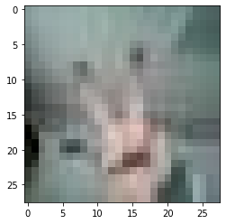

```python
plt.imshow(x_train[0])
print('라벨 :', y_train[0])
```

```
라벨: 1
```

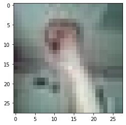

```python
plt.imshow(x_train[150])
print('라벨:', y_train[150])
```

```
라벨: 1
```

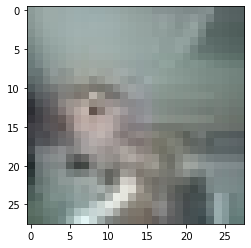

```python
plt.imshow(x_train[190])
print('라벨:', y_train[190])
```